# KNN Classifier

Prajwal C N

17/02/2021

#### Loading R libraries

```r
library(readr)
library(dplyr)
library(fastDummies)
library(ggplot2)
library(caret)
library(class)
library(gmodels)
```

#### Importing the UniversalBank dataset

```r
UniversalBank <- read_csv("UniversalBank.csv")

# Inspecting data
head(UniversalBank)
```

```
## # A tibble: 6 x 14
##      ID   Age Experience Income `ZIP Code` Family CCAvg Education Mortgage
##   <dbl> <dbl>      <dbl>  <dbl>      <dbl>  <dbl> <dbl>     <dbl>    <dbl>
## 1     1    25          1     49      91107      4   1.6         1        0
## 2     2    45         19     34      90089      3   1.5         1        0
## 3     3    39         15     11      94720      1   1           1        0
## 4     4    35          9    100      94112      1   2.7         2        0
## 5     5    35          8     45      91330      4   1           2        0
## 6     6    37         13     29      92121      4   0.4         2      155
## # ... with 5 more variables: `Personal Loan` <dbl>, `Securities Account` <dbl>,
## #   `CD Account` <dbl>, Online <dbl>, CreditCard <dbl>
```

Examining the dataset

```r
glimpse(UniversalBank)
```

```
## Rows: 5,000
## Columns: 14
## $ ID                   <dbl> 1, 2, 3, 4, 5, 6, 7, 8, 9, 10, 11, 12, 13, 14,...
## $ Age                  <dbl> 25, 45, 39, 35, 35, 37, 53, 50, 35, 34, 65, 29...
## $ Experience           <dbl> 1, 19, 15, 9, 8, 13, 27, 24, 10, 9, 39, 5, 23,...
## $ Income               <dbl> 49, 34, 11, 100, 45, 29, 72, 22, 81, 180, 105,...
## $ `ZIP Code`           <dbl> 91107, 90089, 94720, 94112, 91330, 92121, 9171...
## $ Family               <dbl> 4, 3, 1, 1, 4, 4, 2, 1, 3, 1, 4, 3, 2, 4, 1, 1...
## $ CCAvg                <dbl> 1.6, 1.5, 1.0, 2.7, 1.0, 0.4, 1.5, 0.3, 0.6, 8...
## $ Education            <dbl> 1, 1, 1, 2, 2, 2, 2, 3, 2, 3, 3, 2, 3, 2, 1, 3...
## $ Mortgage             <dbl> 0, 0, 0, 0, 0, 155, 0, 0, 104, 0, 0, 0, 0, 0, ...
## $ `Personal Loan`      <dbl> 0, 0, 0, 0, 0, 0, 0, 0, 0, 1, 0, 0, 0, 0, 0, 0...
## $ `Securities Account` <dbl> 1, 1, 0, 0, 0, 0, 0, 0, 0, 0, 0, 0, 1, 0, 1, 0...
## $ `CD Account`         <dbl> 0, 0, 0, 0, 0, 0, 0, 0, 0, 0, 0, 0, 0, 0, 0, 0...
## $ Online               <dbl> 0, 0, 0, 0, 0, 1, 1, 0, 1, 0, 0, 1, 0, 1, 0, 1...
## $ CreditCard           <dbl> 0, 0, 0, 0, 1, 0, 0, 1, 0, 0, 0, 0, 0, 0, 0, 1...
```

Summary statistics of dataset

```r
summary(UniversalBank)
```

```
##        ID            Age          Experience       Income          ZIP Code
##  Min.   :   1   Min.   :23.00   Min.   :-3.0   Min.   :  8.00   Min.   : 9307
##  1st Qu.:1251   1st Qu.:35.00   1st Qu.:10.0   1st Qu.: 39.00   1st Qu.:91911
##  Median :2500   Median :45.00   Median :20.0   Median : 64.00   Median :93437
##  Mean   :2500   Mean   :45.34   Mean   :20.1   Mean   : 73.77   Mean   :93153
##  3rd Qu.:3750   3rd Qu.:55.00   3rd Qu.:30.0   3rd Qu.: 98.00   3rd Qu.:94608
##  Max.   :5000   Max.   :67.00   Max.   :43.0   Max.   :224.00   Max.   :96651
##      Family          CCAvg          Education        Mortgage
##  Min.   :1.000   Min.   : 0.000   Min.   :1.000   Min.   :  0.0
##  1st Qu.:1.000   1st Qu.: 0.700   1st Qu.:1.000   1st Qu.:  0.0
##  Median :2.000   Median : 1.500   Median :2.000   Median :  0.0
##  Mean   :2.396   Mean   : 1.938   Mean   :1.881   Mean   : 56.5
##  3rd Qu.:3.000   3rd Qu.: 2.500   3rd Qu.:3.000   3rd Qu.:101.0
##  Max.   :4.000   Max.   :10.000   Max.   :3.000   Max.   :635.0
##  Personal Loan   Securities Account   CD Account         Online
##  Min.   :0.000   Min.   :0.0000     Min.   :0.0000   Min.   :0.0000
##  1st Qu.:0.000   1st Qu.:0.0000     1st Qu.:0.0000   1st Qu.:0.0000
##  Median :0.000   Median :0.0000     Median :0.0000   Median :1.0000
##  Mean   :0.096   Mean   :0.1044     Mean   :0.0604   Mean   :0.5968
##  3rd Qu.:0.000   3rd Qu.:0.0000     3rd Qu.:0.0000   3rd Qu.:1.0000
##  Max.   :1.000   Max.   :1.0000     Max.   :1.0000   Max.   :1.0000
##    CreditCard
##  Min.   :0.000
##  1st Qu.:0.000
##  Median :0.000
##  Mean   :0.294
##  3rd Qu.:1.000
##  Max.   :1.000
```

#### Data cleaning and Exploratory Data Analysis

From observation, **ID** and **ZIP code** columns are not essential to predict the outcome. Hence dropping these columns.

```r
UniversalBank <- UniversalBank %>% select(-c('ID', "ZIP Code"))
```

Checking NULL values in the dataset at column level.

```r
apply(UniversalBank,2,function(x){any(is.na(x))})
```

```
##                Age         Experience             Income             Family
##              FALSE              FALSE              FALSE              FALSE
##              CCAvg          Education           Mortgage      Personal Loan
##              FALSE              FALSE              FALSE              FALSE
## Securities Account         CD Account             Online         CreditCard
##              FALSE              FALSE              FALSE              FALSE
```

Here **Personal Loan** is a target variable, therefore we must convert into categorical variable. Also, Education level has to be categorical variable.

```r
UniversalBank$`Personal Loan` <- as.factor(UniversalBank$`Personal Loan`)
UniversalBank$Education <- as.factor(UniversalBank$Education)
```

Converting category variable to numeric variable.

```r
UniversalBank_d <- dummy_cols(UniversalBank %>% select(-`Personal Loan`))
UniversalBank_d <- UniversalBank_d %>% select(-Education) %>%
  mutate(`Personal Loan` = UniversalBank$`Personal Loan`)
```

**Visualization**  
Checking the loan acceptance based on the Education Levels.

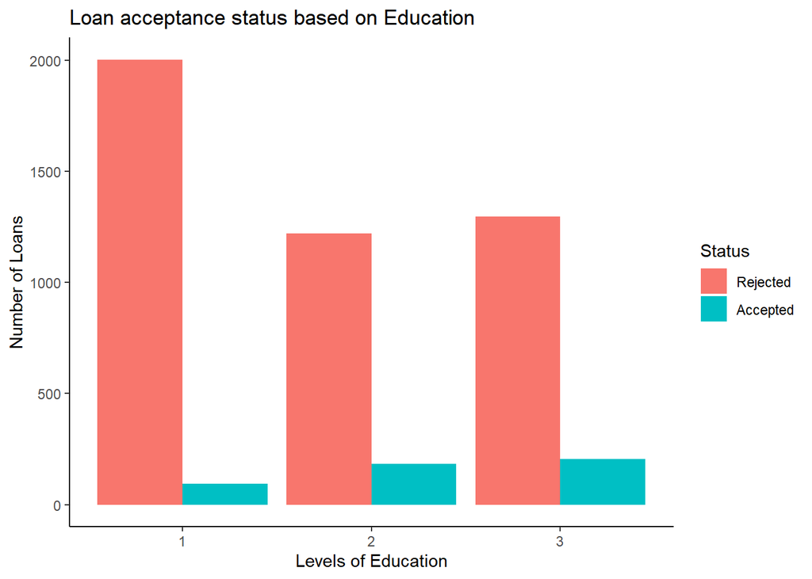

```r
UniversalBank %>% group_by(Education, `Personal Loan`) %>% summarise(count = n()) %>%
ggplot(aes(x = Education, y = count, fill = `Personal Loan`)) + geom_col(position = 'dodge') +
  labs(x = 'Levels of Education', y = 'Number of Loans',
       title = "Loan acceptance status based on Education",
       fill = "Status") + scale_fill_discrete(labels  = c('Rejected','Accepted')) + theme_classic()
```

From above graph we can infer that when education level increases, chances of loan acceptance rate also increase.

Checking the distribution of mortgage column.

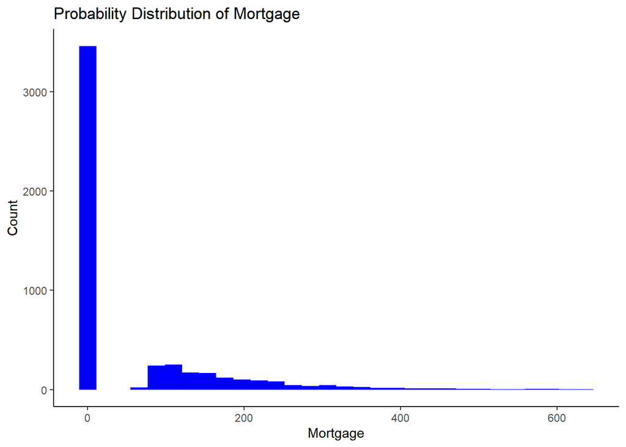

```r
ggplot(UniversalBank, aes(x = Mortgage)) + geom_histogram(fill = 'blue') +
  labs(x="Mortgage", y="Count",title = "Probability Distribution of Mortgage") +
  theme_classic()
```

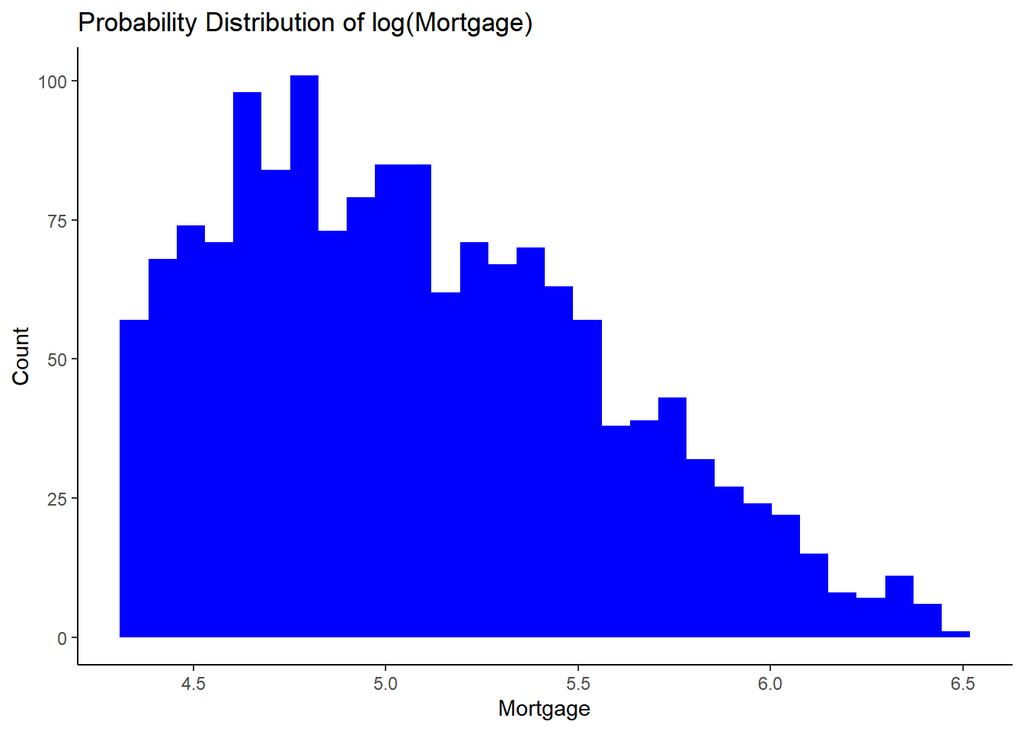

```r
ggplot(UniversalBank, aes(x = log(Mortgage))) + geom_histogram(fill = 'blue') +
  labs(x="Mortgage", y="Count",title = "Probability Distribution of log(Mortgage)") +
  theme_classic()
```

Checking the outliers in ‘Income’ column.

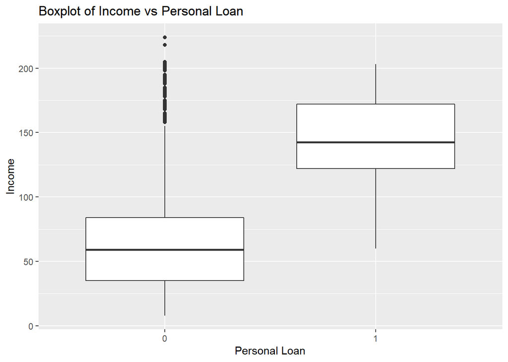

```r
ggplot(UniversalBank, aes(x = `Personal Loan`, y = Income)) + geom_boxplot() +
  labs(title = "Boxplot of Income vs Personal Loan")
```

Checking the outliers in ‘Mortgage’ column.

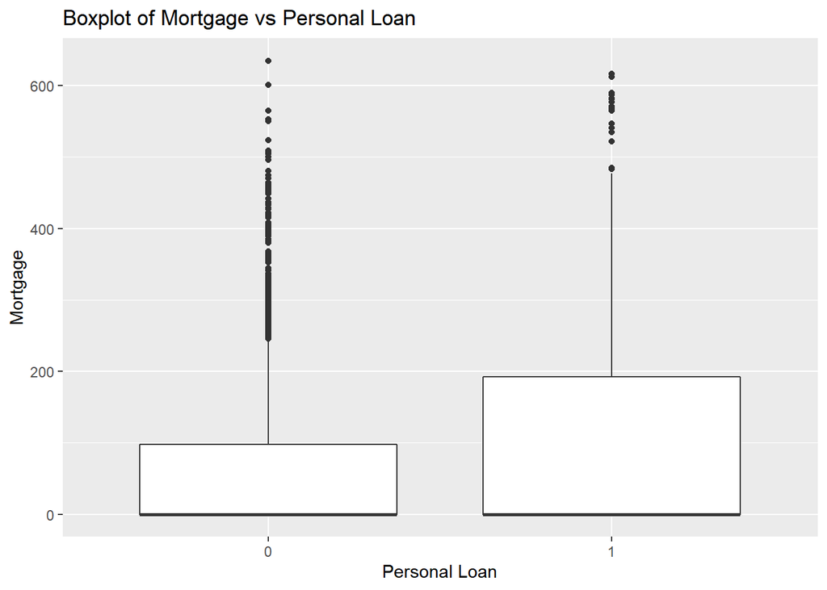

```r
ggplot(UniversalBank, aes(x = `Personal Loan`, y = Mortgage)) + geom_boxplot() +
  labs(title = "Boxplot of Mortgage vs Personal Loan")
```

There seems to be few outliers in both ‘Income’ and ‘Mortgage’ columns.

#### Pre-Processing of data

**Splitting dataset into training (60%) and validation (40%) sets**

```r
set.seed(23)
index <- createDataPartition(UniversalBank_d$`Personal Loan`, p=0.6, list = FALSE)
UniversalBank_train_df <- UniversalBank_d[index,]
UniversalBank_test_df <- UniversalBank_d[-index,]
```

Defining a function to normalize the data.

```r
scale_fun <- preProcess(UniversalBank_train_df[,-14], method = c("center", "scale"))
UniversalBank_train_norm <- predict(scale_fun, UniversalBank_train_df[,-14])
UniversalBank_test_norm <- predict(scale_fun, UniversalBank_test_df[,-14])

# Summary statistics of normalized data
summary(UniversalBank_train_norm)
```

```
##       Age             Experience           Income            Family
##  Min.   :-1.96261   Min.   :-2.02756   Min.   :-1.4395   Min.   :-1.2418
##  1st Qu.:-0.91088   1st Qu.:-0.88815   1st Qu.:-0.7675   1st Qu.:-1.2418
##  Median :-0.03444   Median :-0.01169   Median :-0.2255   Median :-0.3677
##  Mean   : 0.00000   Mean   : 0.00000   Mean   : 0.0000   Mean   : 0.0000
##  3rd Qu.: 0.84199   3rd Qu.: 0.86478   3rd Qu.: 0.5333   3rd Qu.: 0.5064
##  Max.   : 1.89372   Max.   : 2.00419   Max.   : 3.2431   Max.   : 1.3805
##      CCAvg            Mortgage       Securities Account   CD Account
##  Min.   :-1.1194   Min.   :-0.5494   Min.   :-0.3419    Min.   :-0.2585
##  1st Qu.:-0.7233   1st Qu.:-0.5494   1st Qu.:-0.3419    1st Qu.:-0.2585
##  Median :-0.2139   Median :-0.5494   Median :-0.3419    Median :-0.2585
##  Mean   : 0.0000   Mean   : 0.0000   Mean   : 0.0000    Mean   : 0.0000
##  3rd Qu.: 0.3521   3rd Qu.: 0.4314   3rd Qu.:-0.3419    3rd Qu.:-0.2585
##  Max.   : 4.5403   Max.   : 5.7900   Max.   : 2.9243    Max.   : 3.8668
##      Online          CreditCard       Education_1       Education_2
##  Min.   :-1.2169   Min.   :-0.6566   Min.   :-0.8485   Min.   :-0.6137
##  1st Qu.:-1.2169   1st Qu.:-0.6566   1st Qu.:-0.8485   1st Qu.:-0.6137
##  Median : 0.8215   Median :-0.6566   Median :-0.8485   Median :-0.6137
##  Mean   : 0.0000   Mean   : 0.0000   Mean   : 0.0000   Mean   : 0.0000
##  3rd Qu.: 0.8215   3rd Qu.: 1.5224   3rd Qu.: 1.1782   3rd Qu.: 1.6289
##  Max.   : 0.8215   Max.   : 1.5224   Max.   : 1.1782   Max.   : 1.6289
##   Education_3
##  Min.   :-0.6665
##  1st Qu.:-0.6665
##  Median :-0.6665
##  Mean   : 0.0000
##  3rd Qu.: 1.4998
##  Max.   : 1.4998
```

#### Model Construction

*Q1:* Building KNN model with Sample test data and **k=1**.

```r
# Test data
Sample1 <- data.frame(Age = 40, Experience = 10, Income = 84, Family = 2, CCAvg = 2,
                    Mortgage = 0, Securities.Account = 0, CD.Account = 0, Online = 1,
                    CreditCard = 1, Education_1 = 0, Education_2 = 1,Education_3 = 0)
```

**Model**

```r
(knn_model_test1 <- knn(UniversalBank_train_norm,Sample1,
                        cl = UniversalBank_train_df$`Personal Loan`,k = 1, prob = TRUE))
```

```
## [1] 1
## attr(,"prob")
## [1] 1
## Levels: 0 1
```

For the above sample data, model is predicted that loan will be **accepted**.

*Q2:* **Choosing K**

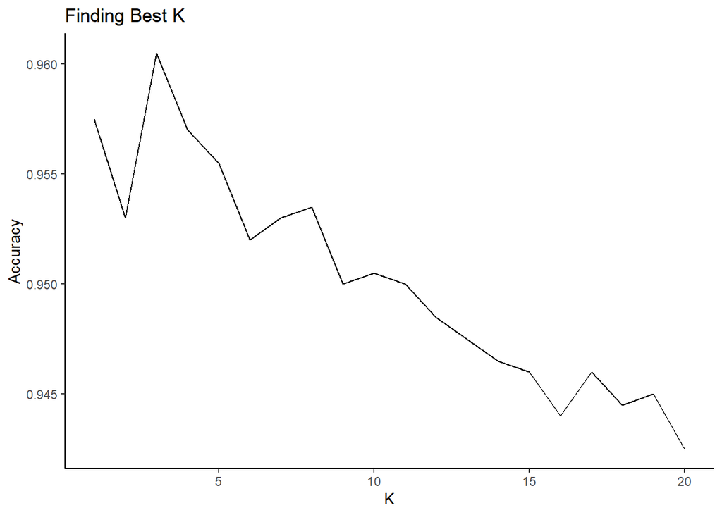

```r
k_choice_df <- data.frame(k = seq(1,20,1), accuracy = rep(0,20))

for(i in 1:20){
  k_choice <- knn(UniversalBank_train_norm,
                  UniversalBank_test_norm, cl = UniversalBank_train_df$`Personal Loan`,
                  k=i)
  k_choice_df[i,2] <- confusionMatrix(k_choice,
                                      UniversalBank_test_df$`Personal Loan`)$overall[1]
}
k_choice_df %>% ggplot(aes(x = k, y = accuracy)) + geom_line() +
  labs(x = "K", y = 'Accuracy', title = 'Finding Best K') +
  theme_classic()
```

```r
head(k_choice_df)
```

```
##   k accuracy
## 1 1   0.9575
## 2 2   0.9530
## 3 3   0.9605
## 4 4   0.9570
## 5 5   0.9555
## 6 6   0.9520
```

```r
best_model <- knn(UniversalBank_train_norm,
                  UniversalBank_test_norm, cl = UniversalBank_train_df$`Personal Loan`,
                  k=4)
```

#### Performance Metrics

```r
Test_labs <- UniversalBank_test_df$`Personal Loan`
predicted_labs <- best_model
CrossTable(x=Test_labs, y =predicted_labs, prop.chisq = FALSE)
```

```
##
##
##    Cell Contents
## |-------------------------|
## |                       N |
## |           N / Row Total |
## |           N / Col Total |
## |         N / Table Total |
## |-------------------------|
##
##
## Total Observations in Table:  2000
##
##
##              | predicted_labs
##    Test_labs |         0 |         1 | Row Total |
## -------------|-----------|-----------|-----------|
##            0 |      1803 |         5 |      1808 |
##              |     0.997 |     0.003 |     0.904 |
##              |     0.958 |     0.043 |           |
##              |     0.901 |     0.002 |           |
## -------------|-----------|-----------|-----------|
##            1 |        80 |       112 |       192 |
##              |     0.417 |     0.583 |     0.096 |
##              |     0.042 |     0.957 |           |
##              |     0.040 |     0.056 |           |
## -------------|-----------|-----------|-----------|
## Column Total |      1883 |       117 |      2000 |
##              |     0.942 |     0.058 |           |
## -------------|-----------|-----------|-----------|
##
##
```

*Q4:* Predicting the sample test data with best model.

```r
(knn_model_test1 <- knn(UniversalBank_train_norm,Sample1,
                        cl = UniversalBank_train_df$`Personal Loan`,k = 4, prob = TRUE))
```

```
## [1] 1
## attr(,"prob")
## [1] 0.75
## Levels: 0 1
```

#### Scenario 2

*Q5:* **Splitting dataset into training, validation, and test sets (50% : 30% : 20%)**

```r
index2 <- createDataPartition(UniversalBank_d$`Personal Loan`, p=0.5, list = FALSE)
UniversalBank_train_df2 <- UniversalBank_d[index2,]
test_val_df2 <- UniversalBank_d[-index2,]
val_id <- createDataPartition(test_val_df2$`Personal Loan`, p=0.6, list = FALSE)
UniversalBank_Validation_df2 <- test_val_df2[val_id,]
UniversalBank_test_df2 <- test_val_df2[-val_id,]

#Data Normalization
scale_fun2 <- preProcess(UniversalBank_train_df2[,-14], method = c("center", "scale"))
UniversalBank_train_norm2 <- predict(scale_fun2, UniversalBank_train_df2[,-14])
UniversalBank_test_norm2 <- predict(scale_fun2, UniversalBank_test_df2[,-14])
UniversalBank_Validation_norm2 <- predict(scale_fun2, UniversalBank_Validation_df2[,-14])
```

```r
best_model2 <- knn(UniversalBank_train_norm2,
                   UniversalBank_Validation_norm2, cl=UniversalBank_train_df2$`Personal Loan`,
                   k=4, prob = TRUE)
```

#### Performance Metrics

Confusion matrix of best model.

```r
Test_labs2 <- UniversalBank_Validation_df2$`Personal Loan`
predicted_labs2 <- best_model2
CrossTable(x=Test_labs2, y =predicted_labs2, prop.chisq = FALSE)
```

```
##
##
##    Cell Contents
## |-------------------------|
## |                       N |
## |           N / Row Total |
## |           N / Col Total |
## |         N / Table Total |
## |-------------------------|
##
##
## Total Observations in Table:  1500
##
##
##              | predicted_labs2
##   Test_labs2 |         0 |         1 | Row Total |
## -------------|-----------|-----------|-----------|
##            0 |      1346 |        10 |      1356 |
##              |     0.993 |     0.007 |     0.904 |
##              |     0.959 |     0.104 |           |
##              |     0.897 |     0.007 |           |
## -------------|-----------|-----------|-----------|
##            1 |        58 |        86 |       144 |
##              |     0.403 |     0.597 |     0.096 |
##              |     0.041 |     0.896 |           |
##              |     0.039 |     0.057 |           |
## -------------|-----------|-----------|-----------|
## Column Total |      1404 |        96 |      1500 |
##              |     0.936 |     0.064 |           |
## -------------|-----------|-----------|-----------|
##
##
```

**Conclusion:**

**From both performance metrics, we can infer that the amount of sample data considered for training causes slight variations in the model accuracy. Hence, more the training data there are more chances of achieving higher accuracy.**